# Reproducible research

# 1. Create a new factor variable in the dataset with two levels - “weekday” and “weekend” indicating whether a given date is a weekday or weekend day.

```r
data1$weekday <- weekdays(data1$date)
data1$weekday[data1$weekday != "Saturday" & data1$weekday != "Sunday"] <- "weekday"
data1$weekday[data1$weekday == "Saturday" | data1$weekday == "Sunday"] <- "weekend"
```

# 2. #Make a panel plot containing a time series plot (i.e. type = “l”) of the 5-minute interval (x-axis) and the average number of steps taken, averaged across all weekday days or weekend days (y-axis). See the README file in the GitHub repository to see an example of what this plot should look like using simulated data.

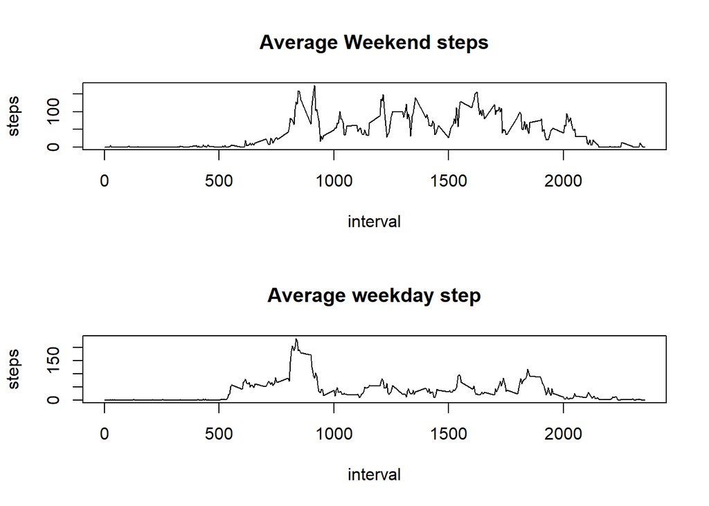